# Survival Analysis of the OPTN/UNOS Data

Sehee Kim

Fan Wu

2016-06-16

# Contents

- Interaction Between Age Group and Diabete Types
- Time-Varying Effect of Diabetes
- Time-Varying Effect of Diabetes Types
- Interaction between Dialysis Time and Diabetes
- Other Raw Output for the Analyses

## Interaction Between Age Group and Diabete Types

For this analysis, patients with either no diabetes or Type I or Type II diabetes are included ($N=$ 92414). Recipient age are categorized, with the frequency in each category as shown below:

```
##
##  [40,60)  [18,40)  [60,75) [75,100)
##    44040    19212    27416     1746
```

We fit the Cox regression models for graft failure and patient death to check the interaction between age groups and the diabetes types. The reference group for age is 40 to 60 years old, and the reference for diabete type is Type II diabetes.

The related coefficients estiamtes for **graft failure** and for **patient death** are shown below. Note the signifiant negative estimate for `DIAB.2_Type I:AGEC3[18,40)` coefficient in the first table for **graft failure**. It implies in patients aged 18-40, Type II diabetes was a higher risk factor for graft failure than Type I diabetes. For other age groups, differences between the two types were not significant. No significant difference in the two diabetes types were found for **patient death**.

We also plot the hazard ratios (HR) for each combination of the age group and the diabetes types (status).

|  | coef | exp(coef) | se(coef) | Pr(>\|z\|) |
| --- | --- | --- | --- | --- |
| DIAB.2_No Diab | -0.341 | 0.711 | 0.027 | 0.000 |
| DIAB.2_Type I | 0.010 | 1.010 | 0.047 | 0.824 |
| AGEC3[18,40) | 0.163 | 1.177 | 0.075 | 0.030 |
| AGEC3[60,75) | 0.275 | 1.317 | 0.028 | 0.000 |
| AGEC3[75,100) | 0.577 | 1.780 | 0.077 | 0.000 |
| DIAB.2_No Diab:AGEC3[18,40) | 0.088 | 1.091 | 0.079 | 0.266 |
| DIAB.2_Type I:AGEC3[18,40) | -0.261 | 0.770 | 0.112 | 0.020 |
| DIAB.2_No Diab:AGEC3[60,75) | 0.080 | 1.083 | 0.037 | 0.029 |
| DIAB.2_Type I:AGEC3[60,75) | -0.028 | 0.972 | 0.078 | 0.719 |
| DIAB.2_No Diab:AGEC3[75,100) | 0.169 | 1.184 | 0.094 | 0.074 |
| DIAB.2_Type I:AGEC3[75,100) | -0.084 | 0.920 | 0.389 | 0.830 |

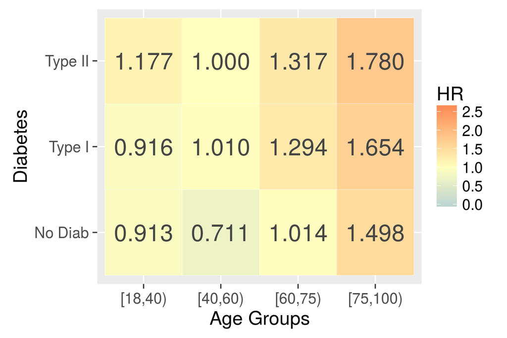

|  | coef | exp(coef) | se(coef) | Pr(>\|z\|) |
| --- | --- | --- | --- | --- |
| DIAB.2_No Diab | -0.653 | 0.520 | 0.034 | 0.000 |
| DIAB.2_Type I | -0.036 | 0.965 | 0.055 | 0.514 |
| AGEC3[18,40) | -0.405 | 0.667 | 0.118 | 0.001 |
| AGEC3[60,75) | 0.477 | 1.611 | 0.032 | 0.000 |
| AGEC3[75,100) | 0.815 | 2.259 | 0.083 | 0.000 |
| DIAB.2_No Diab:AGEC3[18,40) | -0.233 | 0.792 | 0.127 | 0.067 |
| DIAB.2_Type I:AGEC3[18,40) | 0.006 | 1.006 | 0.162 | 0.969 |
| DIAB.2_No Diab:AGEC3[60,75) | 0.292 | 1.338 | 0.043 | 0.000 |
| DIAB.2_Type I:AGEC3[60,75) | -0.017 | 0.984 | 0.087 | 0.848 |
| DIAB.2_No Diab:AGEC3[75,100) | 0.444 | 1.558 | 0.101 | 0.000 |
| DIAB.2_Type I:AGEC3[75,100) | -0.274 | 0.760 | 0.459 | 0.550 |

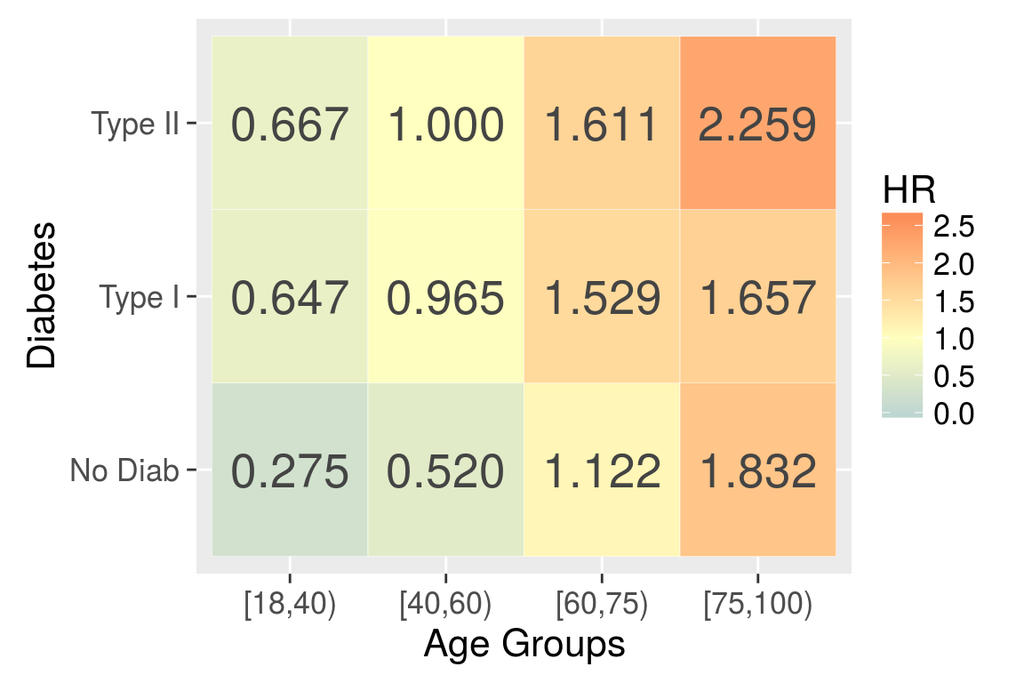

The raw outputs are in the last section.

TOC

## Time-Varying Effect of Diabetes

In this section, we only use the subset with *non-missing diabetes* (N = 94827).

To illustrate the time-varying effect of diabetes, we fit three Cox models (for graft failure and patient death separately) with various forms for the diabetes term (Yes vs. No)

- a single *time-invariant* coefficient assuming proportionality;
- a *piecewise constant time-varying* coefficient with cutting points at 3 months, 6 months, 1 year, 2 years, 3 years, 4 years and 5 years;
- a *smooth time-varying* coefficient using natural cubic B-splines with 3 knots at the quartiles of the observed event times.

From both the piecewise constant fit and the smooth B-spline fit, the deviation from time-invariant effect estimate is obvious. The effect of diabetes starts low (0-3 months) when other risk factors may play a bigger role than later time; it then increases to a larger meganitude (and peaks round 1 year after TX); the diabetes effect comes down a little to a plateau after the first years after TX and then increases almost linearly again after hit the bottom around 2 and a half years after TX.

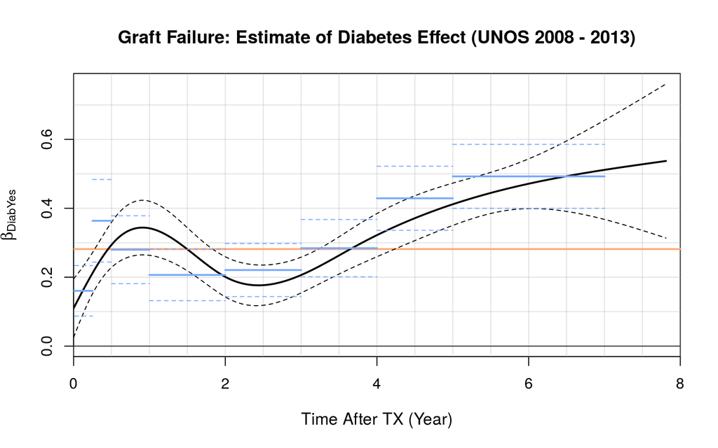

For the diabetes effect estimate for patient death after transplant, the waving trend is less apparent comapring to that of the graft failure. It almost increases linearly throughout out the first 5 years after TX and then reach a plateau around 0.6 (HR = 1.8).

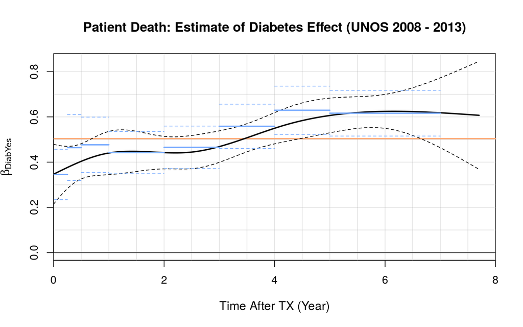

TOC

## Time-Varying Effect of Diabetes Types

In this section, we only use the subset with *No diabetes* or *Type I or Type II Diabetes* (N = 92414). We fit three Cox models to the data similarly as last section, with two time-varying coefficients (For `No Diab` and `Diab I` indicators) in the last two models.

For the graft failure, the estimated time-varying effect of `No Diab` is almost like the mirror image of that of the `DiabYes` in the previous section. However, the time-varying estimate for `Diab I` does not differ much from the time-invariant one, and neither is significantly different from zero.

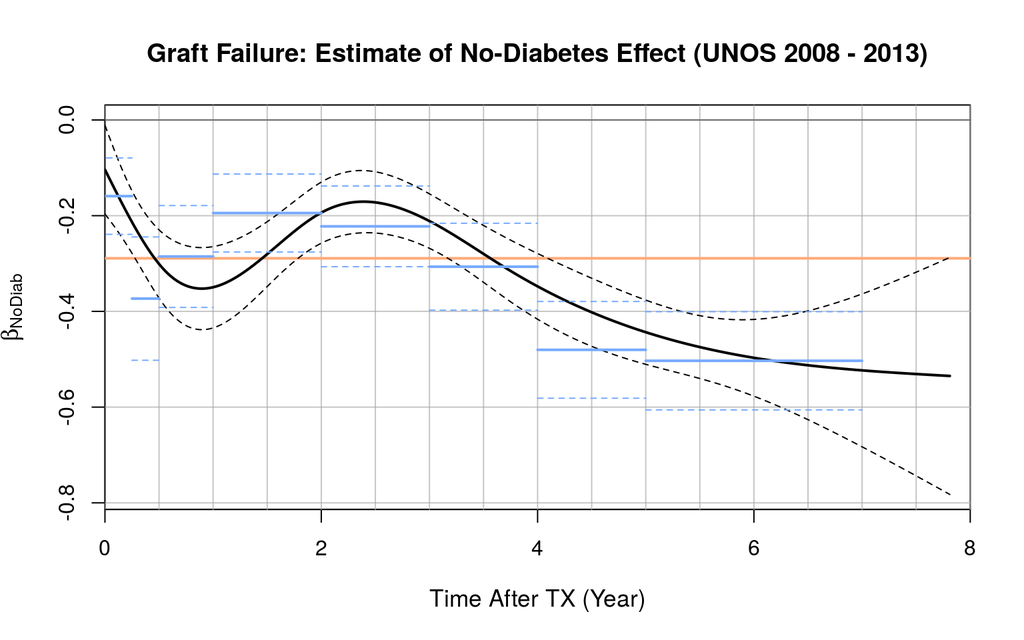

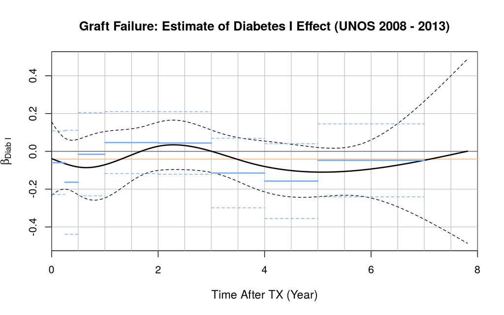

For the patient death, the estimated effect of `No Diab` is decreasing over time after TX, but it is not very far from the time-invariant estimate. On the other hand there is no significant time-varying trend for the `Diab I` effect, showing a similar hazardous effect for both diabetes types.

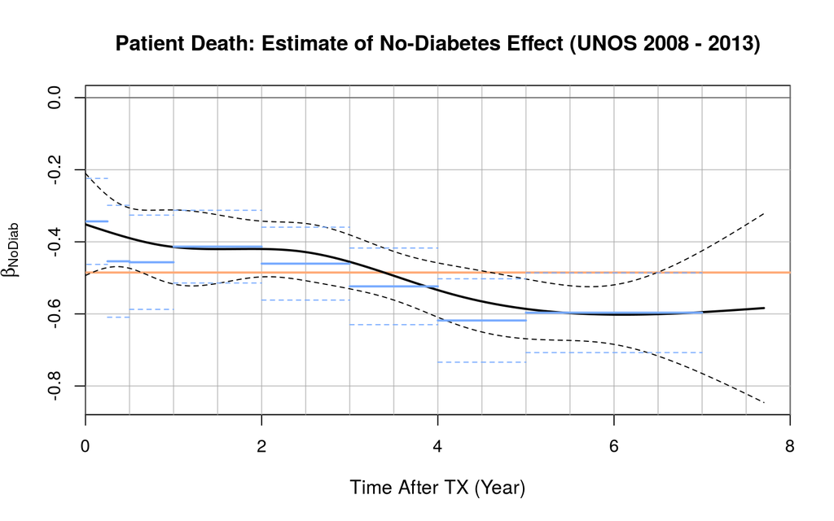

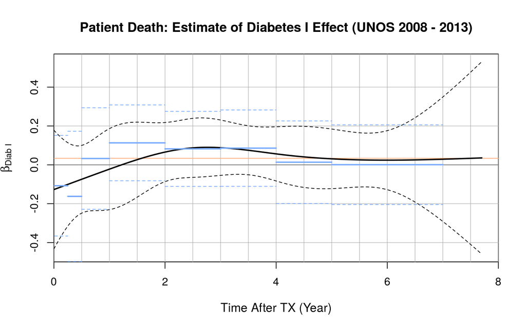

## Interaction between Dialysis Time and Diabetes

Some cross tables:

Donor Type x Dialysis Time

| TDIALC | LD | CD |
| --- | --- | --- |
| Miss | 0.3957399 | 0.6042601 |
| Preemptive | 0.6512842 | 0.3487158 |
| 0-2 | 0.5445587 | 0.4554413 |
| 2+ | 0.1495152 | 0.8504848 |

Dialysis Time x Diabetes Type

|  | Type II | No Diab | Type I |
| --- | --- | --- | --- |
| Miss | 194 ( 0.8%) | 606 ( 1.0%) | 48 ( 0.9%) |
| Preemptive | 2964 (12.3%) | 12544 (19.9%) | 936 (18.3%) |
| 0-2 | 7244 (30.0%) | 17996 (28.5%) | 1750 (34.3%) |
| 2+ | 13761 (57.0%) | 32000 (50.7%) | 2371 (46.4%) |

We fit stratified Cox models with everything including the interaction between diabetes status (Yes or No (reference)) or diabetes types (Diab I, II vs. No) and dialysis time (TDIALC, `Preemptive` as the reference). We fit the models separately for living donors and deceased donors.

Preemptive kidney transplants on average have better suvival outcomes, but the benificial effects is smaller in meganitude for diabetic patients (indicated by negative interaction coefficient estimates), and there is no obvious diabetes type effects.

The related beta estiamtes are shown below (the raw outputs are in the last section).

Graft Failure for Living Donor

|  | coef | exp(coef) | se(coef) | Pr(>\|z\|) |
| --- | --- | --- | --- | --- |
| DIAByes | 0.334 | 1.396 | 0.072 | 0.000 |
| TDIALCMiss | 0.260 | 1.297 | 0.194 | 0.180 |
| TDIALC0-2 | 0.465 | 1.592 | 0.049 | 0.000 |
| TDIALC2+ | 0.612 | 1.844 | 0.057 | 0.000 |
| DIAByes:TDIALCMiss | 0.297 | 1.345 | 0.280 | 0.290 |
| DIAByes:TDIALC0-2 | -0.123 | 0.885 | 0.085 | 0.148 |
| DIAByes:TDIALC2+ | 0.047 | 1.049 | 0.093 | 0.610 |

Patient Death for Living Donor

|  | coef | exp(coef) | se(coef) | Pr(>\|z\|) |
| --- | --- | --- | --- | --- |
| DIAByes | 0.627 | 1.873 | 0.090 | 0.000 |
| TDIALCMiss | 0.332 | 1.393 | 0.280 | 0.236 |
| TDIALC0-2 | 0.489 | 1.630 | 0.072 | 0.000 |
| TDIALC2+ | 0.851 | 2.341 | 0.080 | 0.000 |
| DIAByes:TDIALCMiss | 0.361 | 1.435 | 0.355 | 0.308 |
| DIAByes:TDIALC0-2 | -0.126 | 0.881 | 0.108 | 0.244 |
| DIAByes:TDIALC2+ | -0.034 | 0.966 | 0.116 | 0.768 |

Graft Failure for Deceased Donor

|  | coef | exp(coef) | se(coef) | Pr(>\|z\|) |
| --- | --- | --- | --- | --- |
| DIAByes | 0.332 | 1.393 | 0.068 | 0.000 |
| TDIALCMiss | 0.447 | 1.563 | 0.125 | 0.000 |
| TDIALC0-2 | 0.355 | 1.426 | 0.049 | 0.000 |
| TDIALC2+ | 0.481 | 1.618 | 0.045 | 0.000 |
| DIAByes:TDIALCMiss | 0.115 | 1.122 | 0.202 | 0.569 |
| DIAByes:TDIALC0-2 | -0.098 | 0.907 | 0.078 | 0.210 |
| DIAByes:TDIALC2+ | -0.064 | 0.938 | 0.071 | 0.366 |

Patient Death for Deceased Donor

|  | coef | exp(coef) | se(coef) | Pr(>\|z\|) |
| --- | --- | --- | --- | --- |
| DIAByes | 0.462 | 1.588 | 0.080 | 0.000 |
| TDIALCMiss | 0.299 | 1.348 | 0.167 | 0.073 |
| TDIALC0-2 | 0.356 | 1.428 | 0.062 | 0.000 |
| TDIALC2+ | 0.462 | 1.587 | 0.056 | 0.000 |
| DIAByes:TDIALCMiss | 0.271 | 1.311 | 0.247 | 0.274 |
| DIAByes:TDIALC0-2 | -0.088 | 0.916 | 0.092 | 0.337 |
| DIAByes:TDIALC2+ | 0.040 | 1.041 | 0.083 | 0.629 |

Graft Failure for Living Donor

|  | coef | exp(coef) | se(coef) | Pr(>\|z\|) |
| --- | --- | --- | --- | --- |
| NoDiab | -0.392 | 0.676 | 0.083 | 0.000 |
| DiabI | -0.222 | 0.801 | 0.140 | 0.113 |
| TDIALCMiss | 0.548 | 1.730 | 0.230 | 0.017 |
| TDIALC0-2 | 0.317 | 1.374 | 0.083 | 0.000 |
| TDIALC2+ | 0.613 | 1.846 | 0.090 | 0.000 |
| NoDiab:TDIALCMiss | -0.297 | 0.743 | 0.298 | 0.319 |
| NoDiab:TDIALC0-2 | 0.146 | 1.157 | 0.096 | 0.129 |
| NoDiab:TDIALC2+ | -0.003 | 0.997 | 0.104 | 0.980 |
| DiabI:TDIALCMiss | 0.083 | 1.086 | 0.568 | 0.884 |
| DiabI:TDIALC0-2 | 0.121 | 1.129 | 0.165 | 0.461 |
| DiabI:TDIALC2+ | 0.182 | 1.199 | 0.182 | 0.319 |

Patient Death for Living Donor

|  | coef | exp(coef) | se(coef) | Pr(>\|z\|) |
| --- | --- | --- | --- | --- |
| NoDiab | -0.613 | 0.542 | 0.102 | 0.000 |
| DiabI | -0.065 | 0.937 | 0.168 | 0.700 |
| TDIALCMiss | 0.756 | 2.131 | 0.242 | 0.002 |
| TDIALC0-2 | 0.343 | 1.409 | 0.096 | 0.000 |
| TDIALC2+ | 0.771 | 2.162 | 0.103 | 0.000 |
| NoDiab:TDIALCMiss | -0.435 | 0.647 | 0.367 | 0.235 |
| NoDiab:TDIALC0-2 | 0.144 | 1.155 | 0.120 | 0.229 |
| NoDiab:TDIALC2+ | 0.081 | 1.085 | 0.128 | 0.526 |
| DiabI:TDIALCMiss | -0.340 | 0.712 | 0.771 | 0.659 |
| DiabI:TDIALC0-2 | 0.184 | 1.202 | 0.199 | 0.354 |
| DiabI:TDIALC2+ | 0.236 | 1.266 | 0.213 | 0.267 |

Graft Failure for Deceased Donor

|  | coef | exp(coef) | se(coef) | Pr(>\|z\|) |
| --- | --- | --- | --- | --- |
| NoDiab | -0.328 | 0.721 | 0.074 | 0.000 |
| DiabI | 0.055 | 1.057 | 0.148 | 0.708 |
| TDIALCMiss | 0.590 | 1.804 | 0.194 | 0.002 |
| TDIALC0-2 | 0.262 | 1.299 | 0.068 | 0.000 |
| TDIALC2+ | 0.421 | 1.524 | 0.063 | 0.000 |
| NoDiab:TDIALCMiss | -0.144 | 0.866 | 0.230 | 0.531 |
| NoDiab:TDIALC0-2 | 0.093 | 1.098 | 0.084 | 0.266 |
| NoDiab:TDIALC2+ | 0.060 | 1.061 | 0.077 | 0.437 |
| DiabI:TDIALCMiss | -0.265 | 0.768 | 0.426 | 0.535 |
| DiabI:TDIALC0-2 | -0.081 | 0.922 | 0.170 | 0.633 |
| DiabI:TDIALC2+ | -0.049 | 0.952 | 0.155 | 0.752 |

Patient Death for Deceased Donor

|  | coef | exp(coef) | se(coef) | Pr(>\|z\|) |
| --- | --- | --- | --- | --- |
| NoDiab | -0.418 | 0.658 | 0.087 | 0.000 |
| DiabI | 0.185 | 1.203 | 0.162 | 0.256 |
| TDIALCMiss | 0.695 | 2.003 | 0.215 | 0.001 |
| TDIALC0-2 | 0.307 | 1.359 | 0.078 | 0.000 |
| TDIALC2+ | 0.534 | 1.706 | 0.073 | 0.000 |
| NoDiab:TDIALCMiss | -0.398 | 0.671 | 0.271 | 0.142 |
| NoDiab:TDIALC0-2 | 0.051 | 1.052 | 0.099 | 0.608 |
| NoDiab:TDIALC2+ | -0.068 | 0.935 | 0.091 | 0.454 |
| DiabI:TDIALCMiss | -0.761 | 0.467 | 0.565 | 0.178 |
| DiabI:TDIALC0-2 | -0.231 | 0.794 | 0.190 | 0.225 |
| DiabI:TDIALC2+ | -0.134 | 0.875 | 0.171 | 0.434 |

## Other Raw Output for the Analyses

```r
options(width = 120)
summary(fit.ageint.grf)
```

```
## Call:
## coxph(formula = Surv(T.GRF, D.GRF) ~ DIAB.2_ * AGEC3 + GENDER +
##     ETHCAT + PERIP_VASC + BMI + KDPIC + END_CPRA + CIT + HLAMISM +
##     strata(TX_CTR), data = unos2)
##
##   n= 92414, number of events= 17373
##
##                                   coef exp(coef)  se(coef)       z Pr(>|z|)
## DIAB.2_No Diab               -0.341493  0.710709  0.026849 -12.719  < 2e-16 ***
## DIAB.2_Type I                 0.010401  1.010455  0.046677   0.223 0.823674
## AGEC3[18,40)                  0.162660  1.176636  0.074835   2.174 0.029737 *
## AGEC3[60,75)                  0.275259  1.316871  0.027873   9.875  < 2e-16 ***
## AGEC3[75,100)                 0.576565  1.779913  0.077377   7.451 9.24e-14 ***
## GENDERM                       0.081287  1.084683  0.016202   5.017 5.25e-07 ***
## ETHCATBlack                   0.143759  1.154605  0.019593   7.337 2.18e-13 ***
## ETHCATHispanic               -0.238485  0.787821  0.028525  -8.361  < 2e-16 ***
## ETHCATAsian                  -0.397414  0.672056  0.042442  -9.364  < 2e-16 ***
## ETHCATOther                   0.041295  1.042159  0.062056   0.665 0.505766
## PERIP_VASCYes                 0.347729  1.415849  0.032334  10.754  < 2e-16 ***
## PERIP_VASCUnknown/Miss        0.194707  1.214955  0.053112   3.666 0.000246 ***
## BMIUnderweight                0.128416  1.137026  0.057069   2.250 0.024438 *
## BMIOverweight                -0.005169  0.994844  0.020054  -0.258 0.796593
## BMIObese                      0.079391  1.082628  0.020103   3.949 7.84e-05 ***
## BMIMissing                    0.038964  1.039733  0.154613   0.252 0.801033
## KDPIC10-90                    0.281631  1.325290  0.035930   7.838 4.55e-15 ***
## KDPIC90+                      0.747175  2.111028  0.044067  16.955  < 2e-16 ***
## KDPICLD                      -0.307259  0.735460  0.046105  -6.664 2.66e-11 ***
## KDPICMiss                     0.444605  1.559874  0.092284   4.818 1.45e-06 ***
## END_CPRA[90,100)              0.218111  1.243725  0.034204   6.377 1.81e-10 ***
## END_CPRAMissing               0.205408  1.228026  0.042081   4.881 1.05e-06 ***
## CIT[18,30)                    0.041969  1.042862  0.034909   1.202 0.229274
## CIT[6,18)                    -0.014919  0.985192  0.033460  -0.446 0.655696
## CITMissing                    0.070552  1.073100  0.033373   2.114 0.034510 *
## HLAMISM3-4                    0.137902  1.147863  0.023644   5.833 5.46e-09 ***
## HLAMISM5-6                    0.198731  1.219853  0.023903   8.314  < 2e-16 ***
## HLAMISMMissing                0.630916  1.879331  0.083743   7.534 4.92e-14 ***
## DIAB.2_No Diab:AGEC3[18,40)   0.087506  1.091448  0.078726   1.112 0.266343
## DIAB.2_Type I:AGEC3[18,40)   -0.261067  0.770229  0.112416  -2.322 0.020215 *
## DIAB.2_No Diab:AGEC3[60,75)   0.080150  1.083449  0.036636   2.188 0.028691 *
## DIAB.2_Type I:AGEC3[60,75)   -0.027965  0.972422  0.077763  -0.360 0.719131
```

[output cut: 31 more lines]

```
## HLAMISM3-4                      1.1479     0.8712    1.0959    1.2023
## HLAMISM5-6                      1.2199     0.8198    1.1640    1.2784
## HLAMISMMissing                  1.8793     0.5321    1.5949    2.2146
## DIAB.2_No Diab:AGEC3[18,40)     1.0914     0.9162    0.9354    1.2735
## DIAB.2_Type I:AGEC3[18,40)      0.7702     1.2983    0.6179    0.9601
## DIAB.2_No Diab:AGEC3[60,75)     1.0834     0.9230    1.0084    1.1641
## DIAB.2_Type I:AGEC3[60,75)      0.9724     1.0284    0.8350    1.1325
## DIAB.2_No Diab:AGEC3[75,100)    1.1838     0.8447    0.9838    1.4246
## DIAB.2_Type I:AGEC3[75,100)     0.9199     1.0871    0.4291    1.9719
##
## Concordance= 0.632  (se = 0.026 )
## Rsquare= 0.037   (max possible= 0.885 )
## Likelihood ratio test= 3526  on 34 df,   p=0
## Wald test            = 3542  on 34 df,   p=0
## Score (logrank) test = 3707  on 34 df,   p=0
```

```r
summary(fit.ageint.pt)
```

```
## Call:
## coxph(formula = Surv(T.PT, D.PT) ~ DIAB.2_ * AGEC3 + GENDER +
##     ETHCAT + PERIP_VASC + BMI + KDPIC + END_CPRA + CIT + HLAMISM +
##     strata(TX_CTR), data = unos2)
##
##   n= 92414, number of events= 11011
##
##                                   coef exp(coef)  se(coef)       z Pr(>|z|)
## DIAB.2_No Diab               -0.653129  0.520415  0.034020 -19.198  < 2e-16 ***
## DIAB.2_Type I                -0.035864  0.964772  0.054959  -0.653 0.514045
## AGEC3[18,40)                 -0.405057  0.666939  0.118235  -3.426 0.000613 ***
## AGEC3[60,75)                  0.476888  1.611053  0.032208  14.806  < 2e-16 ***
## AGEC3[75,100)                 0.815048  2.259284  0.083014   9.818  < 2e-16 ***
## GENDERM                       0.151201  1.163230  0.020800   7.269 3.61e-13 ***
## ETHCATBlack                  -0.132376  0.876011  0.025434  -5.205 1.94e-07 ***
## ETHCATHispanic               -0.380353  0.683620  0.036540 -10.409  < 2e-16 ***
## ETHCATAsian                  -0.546391  0.579036  0.053977 -10.123  < 2e-16 ***
## ETHCATOther                  -0.048431  0.952723  0.076985  -0.629 0.529289
## PERIP_VASCYes                 0.470474  1.600753  0.035909  13.102  < 2e-16 ***
## PERIP_VASCUnknown/Miss        0.175883  1.192299  0.065514   2.685 0.007260 **
## BMIUnderweight                0.320587  1.377937  0.071940   4.456 8.34e-06 ***
## BMIOverweight                -0.102845  0.902267  0.025198  -4.082 4.47e-05 ***
## BMIObese                     -0.050130  0.951105  0.025505  -1.966 0.049353 *
## BMIMissing                    0.257575  1.293789  0.170897   1.507 0.131760
## KDPIC10-90                    0.168320  1.183315  0.043550   3.865 0.000111 ***
## KDPIC90+                      0.540488  1.716844  0.053097  10.179  < 2e-16 ***
## KDPICLD                      -0.537804  0.584029  0.057494  -9.354  < 2e-16 ***
## KDPICMiss                     0.376729  1.457509  0.111809   3.369 0.000753 ***
## END_CPRA[90,100)              0.252136  1.286771  0.044882   5.618 1.93e-08 ***
## END_CPRAMissing               0.283559  1.327847  0.053861   5.265 1.40e-07 ***
## CIT[18,30)                    0.003842  1.003850  0.044503   0.086 0.931197
## CIT[6,18)                    -0.015555  0.984565  0.042713  -0.364 0.715721
## CITMissing                    0.019641  1.019836  0.043233   0.454 0.649605
## HLAMISM3-4                    0.094398  1.098997  0.029378   3.213 0.001313 **
## HLAMISM5-6                    0.149481  1.161232  0.029683   5.036 4.76e-07 ***
## HLAMISMMissing                0.777595  2.176232  0.096573   8.052 7.77e-16 ***
## DIAB.2_No Diab:AGEC3[18,40)  -0.232679  0.792408  0.126906  -1.833 0.066733 .
## DIAB.2_Type I:AGEC3[18,40)    0.006252  1.006272  0.162238   0.039 0.969258
## DIAB.2_No Diab:AGEC3[60,75)   0.291539  1.338486  0.043485   6.704 2.02e-11 ***
## DIAB.2_Type I:AGEC3[60,75)   -0.016622  0.983515  0.086741  -0.192 0.848032
```

[output cut: 31 more lines]

```
## HLAMISM3-4                      1.0990     0.9099    1.0375    1.1641
## HLAMISM5-6                      1.1612     0.8612    1.0956    1.2308
## HLAMISMMissing                  2.1762     0.4595    1.8010    2.6297
## DIAB.2_No Diab:AGEC3[18,40)     0.7924     1.2620    0.6179    1.0162
## DIAB.2_Type I:AGEC3[18,40)      1.0063     0.9938    0.7322    1.3830
## DIAB.2_No Diab:AGEC3[60,75)     1.3385     0.7471    1.2291    1.4576
## DIAB.2_Type I:AGEC3[60,75)      0.9835     1.0168    0.8297    1.1658
## DIAB.2_No Diab:AGEC3[75,100)    1.5585     0.6416    1.2776    1.9012
## DIAB.2_Type I:AGEC3[75,100)     0.7601     1.3155    0.3091    1.8695
##
## Concordance= 0.702  (se = 0.033 )
## Rsquare= 0.058   (max possible= 0.739 )
## Likelihood ratio test= 5512  on 34 df,   p=0
## Wald test            = 4979  on 34 df,   p=0
## Score (logrank) test = 5712  on 34 df,   p=0
```

```r
fit.grf <- coxph(Surv(T.GRF, D.GRF) ~ AGEC3 + DIAByes +
                   GENDER + ETHCAT +  PERIP_VASC + BMI + KDPIC +
                   END_CPRA + CIT + HLAMISM + strata(TX_CTR),
                 data = unos1)
summary(fit.grf)
```

```
## Call:
## coxph(formula = Surv(T.GRF, D.GRF) ~ AGEC3 + DIAByes + GENDER +
##     ETHCAT + PERIP_VASC + BMI + KDPIC + END_CPRA + CIT + HLAMISM +
##     strata(TX_CTR), data = unos1)
##
##   n= 94827, number of events= 18022
##
##                            coef exp(coef) se(coef)      z Pr(>|z|)
## AGEC3[18,40)            0.20109   1.22274  0.02209  9.102  < 2e-16 ***
## AGEC3[60,75)            0.32050   1.37782  0.01743 18.392  < 2e-16 ***
## AGEC3[75,100)           0.67283   1.95977  0.04452 15.112  < 2e-16 ***
## DIAByes                 0.28165   1.32531  0.01664 16.925  < 2e-16 ***
## GENDERM                 0.08131   1.08470  0.01587  5.123 3.01e-07 ***
## ETHCATBlack             0.13799   1.14796  0.01916  7.201 5.97e-13 ***
## ETHCATHispanic         -0.23589   0.78987  0.02780 -8.486  < 2e-16 ***
## ETHCATAsian            -0.39397   0.67437  0.04140 -9.515  < 2e-16 ***
## ETHCATOther             0.02442   1.02472  0.06070  0.402  0.68747
## PERIP_VASCYes           0.33806   1.40223  0.03180 10.631  < 2e-16 ***
## PERIP_VASCUnknown/Miss  0.16539   1.17986  0.05032  3.287  0.00101 **
## BMIUnderweight          0.13204   1.14116  0.05637  2.342  0.01916 *
## BMIOverweight          -0.01206   0.98801  0.01970 -0.612  0.54029
## BMIObese                0.07678   1.07981  0.01962  3.913 9.11e-05 ***
## BMIMissing              0.03771   1.03843  0.15029  0.251  0.80189
## KDPIC10-90              0.28058   1.32389  0.03526  7.958 1.78e-15 ***
## KDPIC90+                0.74605   2.10866  0.04310 17.311  < 2e-16 ***
## KDPICLD                -0.31036   0.73319  0.04530 -6.850 7.36e-12 ***
## KDPICMiss               0.44301   1.55738  0.08857  5.002 5.69e-07 ***
## END_CPRA[90,100)        0.20662   1.22952  0.03370  6.132 8.69e-10 ***
## END_CPRAMissing         0.20717   1.23019  0.04163  4.976 6.49e-07 ***
## CIT[18,30)              0.04789   1.04906  0.03433  1.395  0.16300
## CIT[6,18)              -0.01212   0.98795  0.03294 -0.368  0.71287
## CITMissing              0.08259   1.08610  0.03286  2.513  0.01197 *
## HLAMISM3-4              0.13709   1.14693  0.02332  5.879 4.12e-09 ***
## HLAMISM5-6              0.20458   1.22701  0.02354  8.692  < 2e-16 ***
## HLAMISMMissing          0.65020   1.91593  0.08214  7.916 2.44e-15 ***
## ---
## Signif. codes:  0 '***' 0.001 '**' 0.01 '*' 0.05 '.' 0.1 ' ' 1
##
##                        exp(coef) exp(-coef) lower .95 upper .95
## AGEC3[18,40)              1.2227     0.8178    1.1709    1.2768
```

[output cut: 17 more lines]

```
## KDPICMiss                 1.5574     0.6421    1.3092    1.8526
## END_CPRA[90,100)          1.2295     0.8133    1.1509    1.3135
## END_CPRAMissing           1.2302     0.8129    1.1338    1.3348
## CIT[18,30)                1.0491     0.9532    0.9808    1.1221
## CIT[6,18)                 0.9880     1.0122    0.9262    1.0538
## CITMissing                1.0861     0.9207    1.0183    1.1584
## HLAMISM3-4                1.1469     0.8719    1.0957    1.2006
## HLAMISM5-6                1.2270     0.8150    1.1717    1.2849
## HLAMISMMissing            1.9159     0.5219    1.6310    2.2506
##
## Concordance= 0.633  (se = 0.025 )
## Rsquare= 0.038   (max possible= 0.889 )
## Likelihood ratio test= 3654  on 27 df,   p=0
## Wald test            = 3677  on 27 df,   p=0
## Score (logrank) test = 3834  on 27 df,   p=0
```

```r
cox.zph(fit.grf)
```

```
##                              rho    chisq        p
## AGEC3[18,40)            1.27e-02 2.85e+00 9.12e-02
## AGEC3[60,75)            1.99e-02 7.15e+00 7.49e-03
## AGEC3[75,100)           3.26e-02 1.92e+01 1.15e-05
## DIAByes                 3.90e-02 2.80e+01 1.19e-07
## GENDERM                 1.67e-02 5.06e+00 2.45e-02
## ETHCATBlack             1.88e-02 6.42e+00 1.13e-02
## ETHCATHispanic          3.17e-03 1.82e-01 6.69e-01
## ETHCATAsian            -6.33e-03 7.12e-01 3.99e-01
## ETHCATOther            -5.33e-03 5.25e-01 4.69e-01
## PERIP_VASCYes           8.37e-04 1.28e-02 9.10e-01
## PERIP_VASCUnknown/Miss -1.20e-02 2.59e+00 1.07e-01
## BMIUnderweight         -7.81e-03 1.10e+00 2.94e-01
## BMIOverweight          -4.54e-03 3.73e-01 5.41e-01
## BMIObese                1.27e-03 2.92e-02 8.64e-01
## BMIMissing             -1.38e-02 3.48e+00 6.21e-02
## KDPIC10-90             -1.79e-02 5.79e+00 1.62e-02
## KDPIC90+               -2.68e-02 1.30e+01 3.03e-04
## KDPICLD                 9.88e-03 1.80e+00 1.80e-01
## KDPICMiss              -1.78e-03 5.72e-02 8.11e-01
## END_CPRA[90,100)        7.40e-06 9.91e-07 9.99e-01
## END_CPRAMissing        -7.64e-03 1.06e+00 3.02e-01
## CIT[18,30)             -1.50e-02 4.03e+00 4.48e-02
## CIT[6,18)              -6.42e-03 7.42e-01 3.89e-01
## CITMissing             -2.43e-02 1.07e+01 1.10e-03
## HLAMISM3-4              1.72e-03 5.33e-02 8.17e-01
## HLAMISM5-6              7.43e-03 9.87e-01 3.21e-01
## HLAMISMMissing         -3.10e-02 1.75e+01 2.90e-05
## GLOBAL                        NA 1.91e+02 0.00e+00
```

```r
fit.grf <- coxph(Surv(T.GRF, D.GRF) ~ AGEC3 + DIAB.2_ +
                   GENDER + ETHCAT +  PERIP_VASC + BMI + KDPIC +
                   END_CPRA + CIT + HLAMISM + strata(TX_CTR),
                 data = unos2)
summary(fit.grf)
```

```
## Call:
## coxph(formula = Surv(T.GRF, D.GRF) ~ AGEC3 + DIAB.2_ + GENDER +
##     ETHCAT + PERIP_VASC + BMI + KDPIC + END_CPRA + CIT + HLAMISM +
##     strata(TX_CTR), data = unos2)
##
##   n= 92414, number of events= 17373
##
##                             coef exp(coef)  se(coef)       z Pr(>|z|)
## AGEC3[18,40)            0.206904  1.229864  0.022348   9.258  < 2e-16 ***
## AGEC3[60,75)            0.316202  1.371908  0.017974  17.593  < 2e-16 ***
## AGEC3[75,100)           0.677721  1.969385  0.045262  14.973  < 2e-16 ***
## DIAB.2_No Diab         -0.289051  0.748974  0.018418 -15.694  < 2e-16 ***
## DIAB.2_Type I          -0.041081  0.959752  0.034843  -1.179 0.238395
## GENDERM                 0.082656  1.086168  0.016192   5.105 3.31e-07 ***
## ETHCATBlack             0.141775  1.152317  0.019572   7.244 4.36e-13 ***
## ETHCATHispanic         -0.237858  0.788315  0.028511  -8.343  < 2e-16 ***
## ETHCATAsian            -0.398978  0.671005  0.042433  -9.402  < 2e-16 ***
## ETHCATOther             0.041839  1.042726  0.062035   0.674 0.500031
## PERIP_VASCYes           0.351929  1.421807  0.032325  10.887  < 2e-16 ***
## PERIP_VASCUnknown/Miss  0.193912  1.213989  0.053104   3.652 0.000261 ***
## BMIUnderweight          0.131007  1.139976  0.057063   2.296 0.021684 *
## BMIOverweight          -0.006011  0.994007  0.020051  -0.300 0.764330
## BMIObese                0.079419  1.082657  0.020088   3.954 7.70e-05 ***
## BMIMissing              0.044395  1.045396  0.154593   0.287 0.773977
## KDPIC10-90              0.282929  1.327011  0.035932   7.874 3.44e-15 ***
## KDPIC90+                0.749529  2.116003  0.044069  17.008  < 2e-16 ***
## KDPICLD                -0.307315  0.735419  0.046099  -6.666 2.62e-11 ***
## KDPICMiss               0.443362  1.557936  0.092291   4.804 1.56e-06 ***
## END_CPRA[90,100)        0.218077  1.243683  0.034191   6.378 1.79e-10 ***
## END_CPRAMissing         0.205787  1.228492  0.042080   4.890 1.01e-06 ***
## CIT[18,30)              0.042491  1.043407  0.034910   1.217 0.223545
## CIT[6,18)              -0.015097  0.985017  0.033460  -0.451 0.651859
## CITMissing              0.070889  1.073462  0.033370   2.124 0.033642 *
## HLAMISM3-4              0.137889  1.147848  0.023641   5.833 5.46e-09 ***
## HLAMISM5-6              0.198678  1.219790  0.023901   8.313  < 2e-16 ***
## HLAMISMMissing          0.634257  1.885621  0.083737   7.574 3.61e-14 ***
## ---
## Signif. codes:  0 '***' 0.001 '**' 0.01 '*' 0.05 '.' 0.1 ' ' 1
##
##                        exp(coef) exp(-coef) lower .95 upper .95
```

[output cut: 19 more lines]

```
## KDPICMiss                 1.5579     0.6419    1.3001    1.8668
## END_CPRA[90,100)          1.2437     0.8041    1.1631    1.3299
## END_CPRAMissing           1.2285     0.8140    1.1312    1.3341
## CIT[18,30)                1.0434     0.9584    0.9744    1.1173
## CIT[6,18)                 0.9850     1.0152    0.9225    1.0518
## CITMissing                1.0735     0.9316    1.0055    1.1460
## HLAMISM3-4                1.1478     0.8712    1.0959    1.2023
## HLAMISM5-6                1.2198     0.8198    1.1640    1.2783
## HLAMISMMissing            1.8856     0.5303    1.6002    2.2219
##
## Concordance= 0.632  (se = 0.026 )
## Rsquare= 0.037   (max possible= 0.885 )
## Likelihood ratio test= 3504  on 28 df,   p=0
## Wald test            = 3540  on 28 df,   p=0
## Score (logrank) test = 3690  on 28 df,   p=0
```

```r
cox.zph(fit.grf)
```

```
##                              rho    chisq        p
## AGEC3[18,40)            0.014013 3.38e+00 6.59e-02
## AGEC3[60,75)            0.019429 6.59e+00 1.03e-02
## AGEC3[75,100)           0.030854 1.66e+01 4.63e-05
## DIAB.2_No Diab         -0.038982 2.73e+01 1.78e-07
## DIAB.2_Type I          -0.003640 2.34e-01 6.28e-01
## GENDERM                 0.017773 5.52e+00 1.88e-02
## ETHCATBlack             0.017187 5.17e+00 2.29e-02
## ETHCATHispanic          0.002637 1.22e-01 7.27e-01
## ETHCATAsian            -0.008379 1.20e+00 2.73e-01
## ETHCATOther            -0.006139 6.71e-01 4.13e-01
## PERIP_VASCYes          -0.000127 2.83e-04 9.87e-01
## PERIP_VASCUnknown/Miss -0.013658 3.24e+00 7.18e-02
## BMIUnderweight         -0.006419 7.18e-01 3.97e-01
## BMIOverweight          -0.002784 1.35e-01 7.13e-01
## BMIObese                0.001470 3.78e-02 8.46e-01
## BMIMissing             -0.015082 4.04e+00 4.45e-02
## KDPIC10-90             -0.016139 4.51e+00 3.36e-02
## KDPIC90+               -0.023901 9.98e+00 1.58e-03
## KDPICLD                 0.009957 1.77e+00 1.84e-01
## KDPICMiss              -0.002631 1.21e-01 7.28e-01
## END_CPRA[90,100)        0.000116 2.37e-04 9.88e-01
## END_CPRAMissing        -0.006983 8.55e-01 3.55e-01
## CIT[18,30)             -0.017036 5.04e+00 2.47e-02
## CIT[6,18)              -0.007470 9.70e-01 3.25e-01
## CITMissing             -0.027397 1.31e+01 2.97e-04
## HLAMISM3-4              0.000626 6.80e-03 9.34e-01
## HLAMISM5-6              0.005673 5.55e-01 4.56e-01
## HLAMISMMissing         -0.030353 1.61e+01 5.92e-05
## GLOBAL                        NA 1.86e+02 0.00e+00
```

```r
fit.pt <- coxph(Surv(T.PT, D.PT) ~ AGEC3 + DIAByes +
                  GENDER + ETHCAT +  PERIP_VASC + BMI + KDPIC +
                  END_CPRA + CIT + HLAMISM + strata(TX_CTR),
                data = unos1)
summary(fit.pt)
```

```
## Call:
## coxph(formula = Surv(T.PT, D.PT) ~ AGEC3 + DIAByes + GENDER +
##     ETHCAT + PERIP_VASC + BMI + KDPIC + END_CPRA + CIT + HLAMISM +
##     strata(TX_CTR), data = unos1)
##
##   n= 94827, number of events= 11568
##
##                             coef exp(coef)  se(coef)       z Pr(>|z|)
## AGEC3[18,40)           -0.625044  0.535238  0.039392 -15.867  < 2e-16 ***
## AGEC3[60,75)            0.617456  1.854204  0.020688  29.845  < 2e-16 ***
## AGEC3[75,100)           1.061112  2.889583  0.048022  22.096  < 2e-16 ***
## DIAByes                 0.504013  1.655351  0.020362  24.752  < 2e-16 ***
## GENDERM                 0.142086  1.152676  0.020233   7.023 2.18e-12 ***
## ETHCATBlack            -0.142176  0.867468  0.024665  -5.764 8.20e-09 ***
## ETHCATHispanic         -0.381021  0.683164  0.035183 -10.830  < 2e-16 ***
## ETHCATAsian            -0.554543  0.574335  0.052229 -10.617  < 2e-16 ***
## ETHCATOther            -0.093290  0.910929  0.075302  -1.239 0.215386
## PERIP_VASCYes           0.456553  1.578624  0.035245  12.954  < 2e-16 ***
## PERIP_VASCUnknown/Miss  0.135132  1.144688  0.061386   2.201 0.027711 *
## BMIUnderweight          0.314123  1.369058  0.070778   4.438 9.07e-06 ***
## BMIOverweight          -0.110595  0.895302  0.024588  -4.498 6.86e-06 ***
## BMIObese               -0.057530  0.944093  0.024696  -2.330 0.019828 *
## BMIMissing              0.215088  1.239971  0.167397   1.285 0.198828
## KDPIC10-90              0.165331  1.179784  0.042438   3.896 9.79e-05 ***
## KDPIC90+                0.536864  1.710635  0.051628  10.399  < 2e-16 ***
## KDPICLD                -0.545643  0.579469  0.056129  -9.721  < 2e-16 ***
## KDPICMiss               0.334860  1.397745  0.107613   3.112 0.001860 **
## END_CPRA[90,100)        0.228435  1.256632  0.043982   5.194 2.06e-07 ***
## END_CPRAMissing         0.275937  1.317764  0.053157   5.191 2.09e-07 ***
## CIT[18,30)              0.003832  1.003839  0.043462   0.088 0.929750
## CIT[6,18)              -0.016677  0.983461  0.041744  -0.400 0.689515
## CITMissing              0.036400  1.037071  0.042278   0.861 0.389253
## HLAMISM3-4              0.098143  1.103120  0.028847   3.402 0.000668 ***
## HLAMISM5-6              0.160944  1.174620  0.029095   5.532 3.17e-08 ***
## HLAMISMMissing          0.808523  2.244590  0.094281   8.576  < 2e-16 ***
## ---
## Signif. codes:  0 '***' 0.001 '**' 0.01 '*' 0.05 '.' 0.1 ' ' 1
##
##                        exp(coef) exp(-coef) lower .95 upper .95
## AGEC3[18,40)              0.5352     1.8683    0.4955    0.5782
```

[output cut: 17 more lines]

```
## KDPICMiss                 1.3977     0.7154    1.1320    1.7260
## END_CPRA[90,100)          1.2566     0.7958    1.1528    1.3698
## END_CPRAMissing           1.3178     0.7589    1.1874    1.4625
## CIT[18,30)                1.0038     0.9962    0.9219    1.0931
## CIT[6,18)                 0.9835     1.0168    0.9062    1.0673
## CITMissing                1.0371     0.9643    0.9546    1.1267
## HLAMISM3-4                1.1031     0.9065    1.0425    1.1673
## HLAMISM5-6                1.1746     0.8513    1.1095    1.2435
## HLAMISMMissing            2.2446     0.4455    1.8659    2.7002
##
## Concordance= 0.701  (se = 0.032 )
## Rsquare= 0.058   (max possible= 0.749 )
## Likelihood ratio test= 5692  on 27 df,   p=0
## Wald test            = 5310  on 27 df,   p=0
## Score (logrank) test = 5940  on 27 df,   p=0
```

```r
cox.zph(fit.pt)
```

```
##                              rho    chisq        p
## AGEC3[18,40)           -0.001214 1.71e-02 8.96e-01
## AGEC3[60,75)           -0.006009 4.27e-01 5.14e-01
## AGEC3[75,100)           0.018970 4.20e+00 4.05e-02
## DIAByes                 0.027770 9.50e+00 2.05e-03
## GENDERM                 0.003001 1.06e-01 7.45e-01
## ETHCATBlack             0.008684 8.82e-01 3.48e-01
## ETHCATHispanic         -0.002503 7.30e-02 7.87e-01
## ETHCATAsian            -0.013918 2.21e+00 1.37e-01
## ETHCATOther            -0.005784 4.04e-01 5.25e-01
## PERIP_VASCYes           0.009785 1.13e+00 2.88e-01
## PERIP_VASCUnknown/Miss -0.004789 2.66e-01 6.06e-01
## BMIUnderweight         -0.011062 1.43e+00 2.32e-01
## BMIOverweight           0.005497 3.51e-01 5.53e-01
## BMIObese                0.012177 1.74e+00 1.87e-01
## BMIMissing             -0.017659 3.86e+00 4.93e-02
## KDPIC10-90             -0.004147 1.99e-01 6.55e-01
## KDPIC90+               -0.003322 1.29e-01 7.20e-01
## KDPICLD                 0.012689 1.91e+00 1.67e-01
## KDPICMiss               0.006527 4.94e-01 4.82e-01
## END_CPRA[90,100)        0.006716 5.24e-01 4.69e-01
## END_CPRAMissing        -0.000152 2.74e-04 9.87e-01
## CIT[18,30)             -0.004912 2.77e-01 5.99e-01
## CIT[6,18)              -0.004340 2.16e-01 6.42e-01
## CITMissing             -0.012317 1.76e+00 1.85e-01
## HLAMISM3-4              0.000553 3.52e-03 9.53e-01
## HLAMISM5-6              0.008946 9.18e-01 3.38e-01
## HLAMISMMissing         -0.033196 1.27e+01 3.65e-04
## GLOBAL                        NA 6.90e+01 1.57e-05
```

```r
fit.pt <- coxph(Surv(T.PT, D.PT) ~ AGEC3 + DIAB.2_ +
                  GENDER + ETHCAT +  PERIP_VASC + BMI + KDPIC +
                  END_CPRA + CIT + HLAMISM + strata(TX_CTR),
                data = unos2)
summary(fit.pt)
```

```
## Call:
## coxph(formula = Surv(T.PT, D.PT) ~ AGEC3 + DIAB.2_ + GENDER +
##     ETHCAT + PERIP_VASC + BMI + KDPIC + END_CPRA + CIT + HLAMISM +
##     strata(TX_CTR), data = unos2)
##
##   n= 92414, number of events= 11011
##
##                            coef exp(coef) se(coef)       z Pr(>|z|)
## AGEC3[18,40)           -0.63358   0.53069  0.04003 -15.826  < 2e-16 ***
## AGEC3[60,75)            0.62474   1.86776  0.02148  29.086  < 2e-16 ***
## AGEC3[75,100)           1.08152   2.94916  0.04892  22.108  < 2e-16 ***
## DIAB.2_No Diab         -0.48528   0.61552  0.02226 -21.806  < 2e-16 ***
## DIAB.2_Type I           0.03370   1.03428  0.04093   0.823 0.410291
## GENDERM                 0.14867   1.16029  0.02078   7.153 8.47e-13 ***
## ETHCATBlack            -0.13838   0.87077  0.02539  -5.450 5.05e-08 ***
## ETHCATHispanic         -0.38037   0.68361  0.03651 -10.419  < 2e-16 ***
## ETHCATAsian            -0.55426   0.57450  0.05396 -10.271  < 2e-16 ***
## ETHCATOther            -0.04664   0.95443  0.07696  -0.606 0.544447
## PERIP_VASCYes           0.47136   1.60217  0.03592  13.122  < 2e-16 ***
## PERIP_VASCUnknown/Miss  0.17418   1.19027  0.06546   2.661 0.007795 **
## BMIUnderweight          0.31968   1.37668  0.07192   4.445 8.80e-06 ***
## BMIOverweight          -0.10352   0.90166  0.02520  -4.108 4.00e-05 ***
## BMIObese               -0.04840   0.95276  0.02547  -1.900 0.057463 .
## BMIMissing              0.25803   1.29438  0.17092   1.510 0.131134
## KDPIC10-90              0.16612   1.18071  0.04354   3.815 0.000136 ***
## KDPIC90+                0.54219   1.71977  0.05310  10.212  < 2e-16 ***
## KDPICLD                -0.54314   0.58092  0.05747  -9.450  < 2e-16 ***
## KDPICMiss               0.37978   1.46196  0.11183   3.396 0.000684 ***
## END_CPRA[90,100)        0.24291   1.27495  0.04485   5.416 6.09e-08 ***
## END_CPRAMissing         0.28001   1.32314  0.05385   5.200 1.99e-07 ***
## CIT[18,30)              0.00244   1.00244  0.04449   0.055 0.956253
## CIT[6,18)              -0.01646   0.98367  0.04270  -0.386 0.699798
## CITMissing              0.02014   1.02034  0.04321   0.466 0.641233
## HLAMISM3-4              0.09533   1.10002  0.02938   3.244 0.001177 **
## HLAMISM5-6              0.14947   1.16122  0.02969   5.034 4.79e-07 ***
## HLAMISMMissing          0.77981   2.18106  0.09663   8.070 6.66e-16 ***
## ---
## Signif. codes:  0 '***' 0.001 '**' 0.01 '*' 0.05 '.' 0.1 ' ' 1
##
##                        exp(coef) exp(-coef) lower .95 upper .95
```

[output cut: 19 more lines]

```
## KDPICMiss                 1.4620     0.6840    1.1742    1.8202
## END_CPRA[90,100)          1.2750     0.7843    1.1677    1.3921
## END_CPRAMissing           1.3231     0.7558    1.1906    1.4704
## CIT[18,30)                1.0024     0.9976    0.9187    1.0938
## CIT[6,18)                 0.9837     1.0166    0.9047    1.0695
## CITMissing                1.0203     0.9801    0.9375    1.1105
## HLAMISM3-4                1.1000     0.9091    1.0385    1.1652
## HLAMISM5-6                1.1612     0.8612    1.0956    1.2308
## HLAMISMMissing            2.1811     0.4585    1.8047    2.6358
##
## Concordance= 0.702  (se = 0.033 )
## Rsquare= 0.057   (max possible= 0.739 )
## Likelihood ratio test= 5436  on 28 df,   p=0
## Wald test            = 5091  on 28 df,   p=0
## Score (logrank) test = 5707  on 28 df,   p=0
```

```r
cox.zph(fit.pt)
```

```
##                              rho    chisq        p
## AGEC3[18,40)            0.000443  0.00217 9.63e-01
## AGEC3[60,75)           -0.003728  0.15655 6.92e-01
## AGEC3[75,100)           0.018991  4.00345 4.54e-02
## DIAB.2_No Diab         -0.023928  6.72443 9.51e-03
## DIAB.2_Type I           0.003399  0.12890 7.20e-01
## GENDERM                 0.005812  0.37785 5.39e-01
## ETHCATBlack             0.006545  0.47715 4.90e-01
## ETHCATHispanic         -0.004863  0.26407 6.07e-01
## ETHCATAsian            -0.015495  2.61460 1.06e-01
## ETHCATOther            -0.002623  0.07870 7.79e-01
## PERIP_VASCYes           0.008058  0.72997 3.93e-01
## PERIP_VASCUnknown/Miss -0.008638  0.81713 3.66e-01
## BMIUnderweight         -0.008179  0.73952 3.90e-01
## BMIOverweight           0.007950  0.70036 4.03e-01
## BMIObese                0.013914  2.16304 1.41e-01
## BMIMissing             -0.017895  3.73557 5.33e-02
## KDPIC10-90             -0.002491  0.06847 7.94e-01
## KDPIC90+               -0.000961  0.01024 9.19e-01
## KDPICLD                 0.013474  2.05675 1.52e-01
## KDPICMiss               0.005126  0.29103 5.90e-01
## END_CPRA[90,100)        0.006089  0.41006 5.22e-01
## END_CPRAMissing         0.002094  0.04910 8.25e-01
## CIT[18,30)             -0.005321  0.31051 5.77e-01
## CIT[6,18)              -0.002629  0.07574 7.83e-01
## CITMissing             -0.014085  2.19496 1.38e-01
## HLAMISM3-4             -0.001272  0.01776 8.94e-01
## HLAMISM5-6              0.004563  0.22766 6.33e-01
## HLAMISMMissing         -0.034579 13.17573 2.84e-04
## GLOBAL                        NA 64.73415 9.78e-05
```

```r
# LD/DD DIAByes x TDIALC
summary(grf.tdial.LD)
```

```
## Call:
## coxph(formula = Surv(T.GRF, D.GRF) ~ AGEC3 + GENDER + ETHCAT +
##     (NoDiab + DiabI) * TDIALC + PERIP_VASC + BMI + END_CPRA +
##     CIT + HLAMISM + strata(TX_CTR), data = unos2.LD)
##
##   n= 33083, number of events= 4164
##
##                            coef exp(coef) se(coef)      z Pr(>|z|)
## AGEC3[18,40)            0.27630   1.31825  0.04090  6.755 1.43e-11 ***
## AGEC3[60,75)            0.41460   1.51376  0.03926 10.559  < 2e-16 ***
## AGEC3[75,100)           1.03891   2.82613  0.10557  9.841  < 2e-16 ***
## GENDERM                -0.02785   0.97253  0.03330 -0.836 0.402885
## ETHCATBlack             0.24299   1.27505  0.04579  5.306 1.12e-07 ***
## ETHCATHispanic         -0.30139   0.73979  0.05754 -5.238 1.62e-07 ***
## ETHCATAsian            -0.47328   0.62295  0.10211 -4.635 3.57e-06 ***
## ETHCATOther             0.07900   1.08221  0.12729  0.621 0.534826
## NoDiab                 -0.39183   0.67582  0.08302 -4.720 2.36e-06 ***
## DiabI                  -0.22211   0.80083  0.14005 -1.586 0.112748
## TDIALCMiss              0.54808   1.72993  0.22953  2.388 0.016950 *
## TDIALC0-2               0.31749   1.37368  0.08326  3.813 0.000137 ***
## TDIALC2+                0.61317   1.84627  0.08952  6.850 7.41e-12 ***
## PERIP_VASCYes           0.35164   1.42139  0.07067  4.976 6.49e-07 ***
## PERIP_VASCUnknown/Miss -0.06798   0.93427  0.12430 -0.547 0.584417
## BMIUnderweight          0.03948   1.04027  0.10942  0.361 0.718235
## BMIOverweight          -0.02490   0.97540  0.04105 -0.607 0.544080
## BMIObese                0.07228   1.07496  0.04131  1.750 0.080170 .
## BMIMissing             -0.03515   0.96547  0.22955 -0.153 0.878317
## END_CPRA[90,100)        0.27802   1.32051  0.10269  2.707 0.006781 **
## END_CPRAMissing         0.17645   1.19297  0.05246  3.363 0.000770 ***
## CIT[18,30)             -0.30195   0.73938  0.26820 -1.126 0.260242
## CIT[6,18)               0.12503   1.13319  0.11370  1.100 0.271474
## CITMissing              0.01369   1.01379  0.06090  0.225 0.822127
## HLAMISM3-4              0.16525   1.17969  0.03980  4.152 3.30e-05 ***
## HLAMISM5-6              0.18718   1.20584  0.04310  4.343 1.40e-05 ***
## HLAMISMMissing          0.47027   1.60043  0.17117  2.747 0.006006 **
## NoDiab:TDIALCMiss      -0.29719   0.74290  0.29794 -0.997 0.318530
## NoDiab:TDIALC0-2        0.14613   1.15735  0.09620  1.519 0.128744
## NoDiab:TDIALC2+        -0.00258   0.99742  0.10432 -0.025 0.980272
## DiabI:TDIALCMiss        0.08291   1.08645  0.56750  0.146 0.883844
## DiabI:TDIALC0-2         0.12133   1.12900  0.16462  0.737 0.461102
```

[output cut: 29 more lines]

```
## HLAMISM3-4                1.1797     0.8477    1.0912    1.2754
## HLAMISM5-6                1.2058     0.8293    1.1082    1.3121
## HLAMISMMissing            1.6004     0.6248    1.1443    2.2384
## NoDiab:TDIALCMiss         0.7429     1.3461    0.4143    1.3321
## NoDiab:TDIALC0-2          1.1573     0.8640    0.9585    1.3975
## NoDiab:TDIALC2+           0.9974     1.0026    0.8130    1.2237
## DiabI:TDIALCMiss          1.0864     0.9204    0.3572    3.3042
## DiabI:TDIALC0-2           1.1290     0.8857    0.8176    1.5589
## DiabI:TDIALC2+            1.1992     0.8339    0.8391    1.7137
##
## Concordance= 0.621  (se = 0.047 )
## Rsquare= 0.022   (max possible= 0.702 )
## Likelihood ratio test= 733.2  on 33 df,   p=0
## Wald test            = 745.9  on 33 df,   p=0
## Score (logrank) test = 774.9  on 33 df,   p=0
```

```r
summary(mort.tdial.LD)
```

```
## Call:
## coxph(formula = Surv(T.PT, D.PT) ~ AGEC3 + GENDER + ETHCAT +
##     (NoDiab + DiabI) * TDIALC + PERIP_VASC + BMI + END_CPRA +
##     CIT + HLAMISM + strata(TX_CTR), data = unos2.LD)
##
##   n= 33083, number of events= 2369
##
##                            coef exp(coef) se(coef)      z Pr(>|z|)
## AGEC3[18,40)           -0.67764   0.50782  0.07482 -9.057  < 2e-16 ***
## AGEC3[60,75)            0.78055   2.18268  0.04737 16.477  < 2e-16 ***
## AGEC3[75,100)           1.49999   4.48164  0.11247 13.337  < 2e-16 ***
## GENDERM                 0.15257   1.16482  0.04601  3.316 0.000913 ***
## ETHCATBlack            -0.13691   0.87205  0.06859 -1.996 0.045928 *
## ETHCATHispanic         -0.47432   0.62231  0.08098 -5.857 4.71e-09 ***
## ETHCATAsian            -0.52482   0.59166  0.14038 -3.739 0.000185 ***
## ETHCATOther             0.01314   1.01322  0.16239  0.081 0.935523
## NoDiab                 -0.61323   0.54160  0.10180 -6.024 1.70e-09 ***
## DiabI                  -0.06498   0.93709  0.16834 -0.386 0.699502
## TDIALCMiss              0.75648   2.13077  0.24213  3.124 0.001782 **
## TDIALC0-2               0.34280   1.40889  0.09641  3.556 0.000377 ***
## TDIALC2+                0.77087   2.16165  0.10270  7.506 6.10e-14 ***
## PERIP_VASCYes           0.50385   1.65508  0.07705  6.539 6.18e-11 ***
## PERIP_VASCUnknown/Miss -0.19021   0.82679  0.16541 -1.150 0.250180
## BMIUnderweight          0.28379   1.32816  0.15439  1.838 0.066047 .
## BMIOverweight          -0.16724   0.84600  0.05525 -3.027 0.002468 **
## BMIObese               -0.07387   0.92879  0.05562 -1.328 0.184168
## BMIMissing              0.33777   1.40181  0.25232  1.339 0.180691
## END_CPRA[90,100)        0.21500   1.23986  0.14921  1.441 0.149612
## END_CPRAMissing         0.21329   1.23774  0.06858  3.110 0.001872 **
## CIT[18,30)             -0.43706   0.64593  0.36617 -1.194 0.232629
## CIT[6,18)               0.02239   1.02264  0.16016  0.140 0.888846
## CITMissing             -0.08433   0.91913  0.08335 -1.012 0.311642
## HLAMISM3-4              0.06905   1.07149  0.05210  1.325 0.185076
## HLAMISM5-6              0.08263   1.08614  0.05709  1.447 0.147780
## HLAMISMMissing          0.24687   1.28001  0.24365  1.013 0.310962
## NoDiab:TDIALCMiss      -0.43546   0.64697  0.36672 -1.187 0.235047
## NoDiab:TDIALC0-2        0.14446   1.15541  0.12006  1.203 0.228888
## NoDiab:TDIALC2+         0.08145   1.08486  0.12830  0.635 0.525529
## DiabI:TDIALCMiss       -0.33986   0.71187  0.77117 -0.441 0.659419
## DiabI:TDIALC0-2         0.18414   1.20218  0.19864  0.927 0.353929
```

[output cut: 29 more lines]

```
## HLAMISM3-4                1.0715     0.9333    0.9675    1.1867
## HLAMISM5-6                1.0861     0.9207    0.9712    1.2147
## HLAMISMMissing            1.2800     0.7812    0.7940    2.0635
## NoDiab:TDIALCMiss         0.6470     1.5457    0.3153    1.3275
## NoDiab:TDIALC0-2          1.1554     0.8655    0.9132    1.4619
## NoDiab:TDIALC2+           1.0849     0.9218    0.8436    1.3950
## DiabI:TDIALCMiss          0.7119     1.4048    0.1570    3.2271
## DiabI:TDIALC0-2           1.2022     0.8318    0.8145    1.7744
## DiabI:TDIALC2+            1.2661     0.7898    0.8348    1.9202
##
## Concordance= 0.718  (se = 0.062 )
## Rsquare= 0.041   (max possible= 0.491 )
## Likelihood ratio test= 1390  on 33 df,   p=0
## Wald test            = 1372  on 33 df,   p=0
## Score (logrank) test = 1600  on 33 df,   p=0
```

```r
summary(grf.tdial.DD)
```

```
## Call:
## coxph(formula = Surv(T.GRF, D.GRF) ~ AGEC + GENDER + ETHCAT +
##     (NoDiab + DiabI) * TDIALC + PERIP_VASC + BMI + KDPIC + END_CPRA +
##     CIT + HLAMISM + strata(TX_CTR), data = unos2.DD)
##
##   n= 59331, number of events= 13209
##
##                             coef exp(coef)  se(coef)      z Pr(>|z|)
## AGEC[40,60)            -0.159970  0.852169  0.027190 -5.884 4.02e-09 ***
## AGEC[60,75)             0.134127  1.143538  0.029114  4.607 4.09e-06 ***
## AGEC[75,100)            0.429092  1.535862  0.054423  7.884 3.11e-15 ***
## GENDERM                 0.098847  1.103898  0.018674  5.293 1.20e-07 ***
## ETHCATBlack             0.043726  1.044697  0.022207  1.969 0.048947 *
## ETHCATHispanic         -0.293692  0.745506  0.033226 -8.839  < 2e-16 ***
## ETHCATAsian            -0.446043  0.640156  0.047238 -9.442  < 2e-16 ***
## ETHCATOther            -0.040838  0.959985  0.071590 -0.570 0.568380
## NoDiab                 -0.327520  0.720709  0.073794 -4.438 9.07e-06 ***
## DiabI                   0.055322  1.056881  0.147607  0.375 0.707813
## TDIALCMiss              0.589981  1.803955  0.193892  3.043 0.002344 **
## TDIALC0-2               0.261523  1.298907  0.068073  3.842 0.000122 ***
## TDIALC2+                0.421343  1.524007  0.063344  6.652 2.90e-11 ***
## PERIP_VASCYes           0.312670  1.367070  0.036635  8.535  < 2e-16 ***
## PERIP_VASCUnknown/Miss  0.232069  1.261207  0.059767  3.883 0.000103 ***
## BMIUnderweight          0.166656  1.181348  0.067221  2.479 0.013166 *
## BMIOverweight           0.004795  1.004806  0.023101  0.208 0.835580
## BMIObese                0.076078  1.079047  0.023169  3.284 0.001025 **
## BMIMissing             -0.023170  0.977097  0.216870 -0.107 0.914919
## KDPIC10-90              0.268658  1.308208  0.036068  7.449 9.43e-14 ***
## KDPIC90+                0.733463  2.082279  0.044570 16.456  < 2e-16 ***
## KDPICMiss               0.420725  1.523065  0.092533  4.547 5.45e-06 ***
## END_CPRA[90,100)        0.182308  1.199983  0.036660  4.973 6.59e-07 ***
## END_CPRAMissing         0.402075  1.494924  0.100101  4.017 5.90e-05 ***
## CIT[18,30)              0.061449  1.063376  0.046656  1.317 0.187817
## CIT[6,18)               0.003879  1.003886  0.044960  0.086 0.931250
## CITMissing              0.095667  1.100393  0.053016  1.805 0.071153 .
## HLAMISM3-4              0.109224  1.115412  0.030207  3.616 0.000299 ***
## HLAMISM5-6              0.186866  1.205466  0.030080  6.212 5.22e-10 ***
## HLAMISMMissing          0.856586  2.355106  0.102170  8.384  < 2e-16 ***
## NoDiab:TDIALCMiss      -0.144044  0.865849  0.230106 -0.626 0.531320
## NoDiab:TDIALC0-2        0.093360  1.097856  0.083965  1.112 0.266188
```

[output cut: 35 more lines]

```
## HLAMISM3-4                1.1154     0.8965    1.0513    1.1834
## HLAMISM5-6                1.2055     0.8296    1.1365    1.2787
## HLAMISMMissing            2.3551     0.4246    1.9277    2.8772
## NoDiab:TDIALCMiss         0.8658     1.1549    0.5515    1.3593
## NoDiab:TDIALC0-2          1.0979     0.9109    0.9313    1.2942
## NoDiab:TDIALC2+           1.0614     0.9422    0.9132    1.2336
## DiabI:TDIALCMiss          0.7676     1.3028    0.3329    1.7697
## DiabI:TDIALC0-2           0.9221     1.0844    0.6612    1.2861
## DiabI:TDIALC2+            0.9524     1.0500    0.7034    1.2895
##
## Concordance= 0.597  (se = 0.03 )
## Rsquare= 0.029   (max possible= 0.907 )
## Likelihood ratio test= 1749  on 36 df,   p=0
## Wald test            = 1787  on 36 df,   p=0
## Score (logrank) test = 1828  on 36 df,   p=0
```

```r
summary(mort.tdial.DD)
```

```
## Call:
## coxph(formula = Surv(T.PT, D.PT) ~ AGEC + GENDER + ETHCAT + (NoDiab +
##     DiabI) * TDIALC + PERIP_VASC + BMI + KDPIC + END_CPRA + CIT +
##     HLAMISM + strata(TX_CTR), data = unos2.DD)
##
##   n= 59331, number of events= 8642
##
##                             coef exp(coef)  se(coef)       z Pr(>|z|)
## AGEC[40,60)             0.616693  1.852791  0.047826  12.895  < 2e-16 ***
## AGEC[60,75)             1.207449  3.344939  0.048584  24.853  < 2e-16 ***
## AGEC[75,100)            1.595210  4.929366  0.068969  23.130  < 2e-16 ***
## GENDERM                 0.128144  1.136717  0.023486   5.456 4.86e-08 ***
## ETHCATBlack            -0.225910  0.797790  0.028080  -8.045 8.88e-16 ***
## ETHCATHispanic         -0.439978  0.644051  0.041407 -10.626  < 2e-16 ***
## ETHCATAsian            -0.620098  0.537891  0.059120 -10.489  < 2e-16 ***
## ETHCATOther            -0.169103  0.844422  0.088539  -1.910 0.056143 .
## NoDiab                 -0.418415  0.658089  0.086764  -4.822 1.42e-06 ***
## DiabI                   0.184679  1.202833  0.162420   1.137 0.255519
## TDIALCMiss              0.694703  2.003115  0.214544   3.238 0.001204 **
## TDIALC0-2               0.306577  1.358766  0.077900   3.936 8.30e-05 ***
## TDIALC2+                0.533885  1.705546  0.072717   7.342 2.10e-13 ***
## PERIP_VASCYes           0.410053  1.506897  0.041124   9.971  < 2e-16 ***
## PERIP_VASCUnknown/Miss  0.210052  1.233743  0.072780   2.886 0.003900 **
## BMIUnderweight          0.334636  1.397431  0.081753   4.093 4.25e-05 ***
## BMIOverweight          -0.084881  0.918622  0.028492  -2.979 0.002891 **
## BMIObese               -0.051287  0.950006  0.028895  -1.775 0.075908 .
## BMIMissing              0.070328  1.072860  0.247995   0.284 0.776727
## KDPIC10-90              0.154099  1.166606  0.043690   3.527 0.000420 ***
## KDPIC90+                0.536362  1.709776  0.053670   9.994  < 2e-16 ***
## KDPICMiss               0.370420  1.448342  0.112154   3.303 0.000957 ***
## END_CPRA[90,100)        0.205891  1.228619  0.047529   4.332 1.48e-05 ***
## END_CPRAMissing         0.513474  1.671087  0.125950   4.077 4.57e-05 ***
## CIT[18,30)              0.030227  1.030688  0.058240   0.519 0.603760
## CIT[6,18)               0.006213  1.006233  0.056104   0.111 0.911819
## CITMissing              0.045963  1.047036  0.066239   0.694 0.487741
## HLAMISM3-4              0.099373  1.104479  0.036609   2.714 0.006639 **
## HLAMISM5-6              0.161268  1.175000  0.036460   4.423 9.73e-06 ***
## HLAMISMMissing          1.111058  3.037569  0.113151   9.819  < 2e-16 ***
## NoDiab:TDIALCMiss      -0.398351  0.671426  0.270967  -1.470 0.141532
## NoDiab:TDIALC0-2        0.050809  1.052122  0.099149   0.512 0.608336
```

[output cut: 35 more lines]

```
## HLAMISM3-4                1.1045     0.9054    1.0280    1.1866
## HLAMISM5-6                1.1750     0.8511    1.0940    1.2620
## HLAMISMMissing            3.0376     0.3292    2.4334    3.7918
## NoDiab:TDIALCMiss         0.6714     1.4894    0.3948    1.1419
## NoDiab:TDIALC0-2          1.0521     0.9505    0.8663    1.2778
## NoDiab:TDIALC2+           0.9345     1.0701    0.7825    1.1160
## DiabI:TDIALCMiss          0.4674     2.1397    0.1543    1.4153
## DiabI:TDIALC0-2           0.7939     1.2596    0.5466    1.1530
## DiabI:TDIALC2+            0.8749     1.1430    0.6260    1.2227
##
## Concordance= 0.668  (se = 0.038 )
## Rsquare= 0.051   (max possible= 0.78 )
## Likelihood ratio test= 3088  on 36 df,   p=0
## Wald test            = 2966  on 36 df,   p=0
## Score (logrank) test = 3221  on 36 df,   p=0
```

```r
# LD/DD Diab Type x TDIALC
summary(grf.tdial.LD)
```

```
## Call:
## coxph(formula = Surv(T.GRF, D.GRF) ~ AGEC3 + GENDER + ETHCAT +
##     (NoDiab + DiabI) * TDIALC + PERIP_VASC + BMI + END_CPRA +
##     CIT + HLAMISM + strata(TX_CTR), data = unos2.LD)
##
##   n= 33083, number of events= 4164
##
##                            coef exp(coef) se(coef)      z Pr(>|z|)
## AGEC3[18,40)            0.27630   1.31825  0.04090  6.755 1.43e-11 ***
## AGEC3[60,75)            0.41460   1.51376  0.03926 10.559  < 2e-16 ***
## AGEC3[75,100)           1.03891   2.82613  0.10557  9.841  < 2e-16 ***
## GENDERM                -0.02785   0.97253  0.03330 -0.836 0.402885
## ETHCATBlack             0.24299   1.27505  0.04579  5.306 1.12e-07 ***
## ETHCATHispanic         -0.30139   0.73979  0.05754 -5.238 1.62e-07 ***
## ETHCATAsian            -0.47328   0.62295  0.10211 -4.635 3.57e-06 ***
## ETHCATOther             0.07900   1.08221  0.12729  0.621 0.534826
## NoDiab                 -0.39183   0.67582  0.08302 -4.720 2.36e-06 ***
## DiabI                  -0.22211   0.80083  0.14005 -1.586 0.112748
## TDIALCMiss              0.54808   1.72993  0.22953  2.388 0.016950 *
## TDIALC0-2               0.31749   1.37368  0.08326  3.813 0.000137 ***
## TDIALC2+                0.61317   1.84627  0.08952  6.850 7.41e-12 ***
## PERIP_VASCYes           0.35164   1.42139  0.07067  4.976 6.49e-07 ***
## PERIP_VASCUnknown/Miss -0.06798   0.93427  0.12430 -0.547 0.584417
## BMIUnderweight          0.03948   1.04027  0.10942  0.361 0.718235
## BMIOverweight          -0.02490   0.97540  0.04105 -0.607 0.544080
## BMIObese                0.07228   1.07496  0.04131  1.750 0.080170 .
## BMIMissing             -0.03515   0.96547  0.22955 -0.153 0.878317
## END_CPRA[90,100)        0.27802   1.32051  0.10269  2.707 0.006781 **
## END_CPRAMissing         0.17645   1.19297  0.05246  3.363 0.000770 ***
## CIT[18,30)             -0.30195   0.73938  0.26820 -1.126 0.260242
## CIT[6,18)               0.12503   1.13319  0.11370  1.100 0.271474
## CITMissing              0.01369   1.01379  0.06090  0.225 0.822127
## HLAMISM3-4              0.16525   1.17969  0.03980  4.152 3.30e-05 ***
## HLAMISM5-6              0.18718   1.20584  0.04310  4.343 1.40e-05 ***
## HLAMISMMissing          0.47027   1.60043  0.17117  2.747 0.006006 **
## NoDiab:TDIALCMiss      -0.29719   0.74290  0.29794 -0.997 0.318530
## NoDiab:TDIALC0-2        0.14613   1.15735  0.09620  1.519 0.128744
## NoDiab:TDIALC2+        -0.00258   0.99742  0.10432 -0.025 0.980272
## DiabI:TDIALCMiss        0.08291   1.08645  0.56750  0.146 0.883844
## DiabI:TDIALC0-2         0.12133   1.12900  0.16462  0.737 0.461102
```

[output cut: 29 more lines]

```
## HLAMISM3-4                1.1797     0.8477    1.0912    1.2754
## HLAMISM5-6                1.2058     0.8293    1.1082    1.3121
## HLAMISMMissing            1.6004     0.6248    1.1443    2.2384
## NoDiab:TDIALCMiss         0.7429     1.3461    0.4143    1.3321
## NoDiab:TDIALC0-2          1.1573     0.8640    0.9585    1.3975
## NoDiab:TDIALC2+           0.9974     1.0026    0.8130    1.2237
## DiabI:TDIALCMiss          1.0864     0.9204    0.3572    3.3042
## DiabI:TDIALC0-2           1.1290     0.8857    0.8176    1.5589
## DiabI:TDIALC2+            1.1992     0.8339    0.8391    1.7137
##
## Concordance= 0.621  (se = 0.047 )
## Rsquare= 0.022   (max possible= 0.702 )
## Likelihood ratio test= 733.2  on 33 df,   p=0
## Wald test            = 745.9  on 33 df,   p=0
## Score (logrank) test = 774.9  on 33 df,   p=0
```

```r
summary(mort.tdial.LD)
```

```
## Call:
## coxph(formula = Surv(T.PT, D.PT) ~ AGEC3 + GENDER + ETHCAT +
##     (NoDiab + DiabI) * TDIALC + PERIP_VASC + BMI + END_CPRA +
##     CIT + HLAMISM + strata(TX_CTR), data = unos2.LD)
##
##   n= 33083, number of events= 2369
##
##                            coef exp(coef) se(coef)      z Pr(>|z|)
## AGEC3[18,40)           -0.67764   0.50782  0.07482 -9.057  < 2e-16 ***
## AGEC3[60,75)            0.78055   2.18268  0.04737 16.477  < 2e-16 ***
## AGEC3[75,100)           1.49999   4.48164  0.11247 13.337  < 2e-16 ***
## GENDERM                 0.15257   1.16482  0.04601  3.316 0.000913 ***
## ETHCATBlack            -0.13691   0.87205  0.06859 -1.996 0.045928 *
## ETHCATHispanic         -0.47432   0.62231  0.08098 -5.857 4.71e-09 ***
## ETHCATAsian            -0.52482   0.59166  0.14038 -3.739 0.000185 ***
## ETHCATOther             0.01314   1.01322  0.16239  0.081 0.935523
## NoDiab                 -0.61323   0.54160  0.10180 -6.024 1.70e-09 ***
## DiabI                  -0.06498   0.93709  0.16834 -0.386 0.699502
## TDIALCMiss              0.75648   2.13077  0.24213  3.124 0.001782 **
## TDIALC0-2               0.34280   1.40889  0.09641  3.556 0.000377 ***
## TDIALC2+                0.77087   2.16165  0.10270  7.506 6.10e-14 ***
## PERIP_VASCYes           0.50385   1.65508  0.07705  6.539 6.18e-11 ***
## PERIP_VASCUnknown/Miss -0.19021   0.82679  0.16541 -1.150 0.250180
## BMIUnderweight          0.28379   1.32816  0.15439  1.838 0.066047 .
## BMIOverweight          -0.16724   0.84600  0.05525 -3.027 0.002468 **
## BMIObese               -0.07387   0.92879  0.05562 -1.328 0.184168
## BMIMissing              0.33777   1.40181  0.25232  1.339 0.180691
## END_CPRA[90,100)        0.21500   1.23986  0.14921  1.441 0.149612
## END_CPRAMissing         0.21329   1.23774  0.06858  3.110 0.001872 **
## CIT[18,30)             -0.43706   0.64593  0.36617 -1.194 0.232629
## CIT[6,18)               0.02239   1.02264  0.16016  0.140 0.888846
## CITMissing             -0.08433   0.91913  0.08335 -1.012 0.311642
## HLAMISM3-4              0.06905   1.07149  0.05210  1.325 0.185076
## HLAMISM5-6              0.08263   1.08614  0.05709  1.447 0.147780
## HLAMISMMissing          0.24687   1.28001  0.24365  1.013 0.310962
## NoDiab:TDIALCMiss      -0.43546   0.64697  0.36672 -1.187 0.235047
## NoDiab:TDIALC0-2        0.14446   1.15541  0.12006  1.203 0.228888
## NoDiab:TDIALC2+         0.08145   1.08486  0.12830  0.635 0.525529
## DiabI:TDIALCMiss       -0.33986   0.71187  0.77117 -0.441 0.659419
## DiabI:TDIALC0-2         0.18414   1.20218  0.19864  0.927 0.353929
```

[output cut: 29 more lines]

```
## HLAMISM3-4                1.0715     0.9333    0.9675    1.1867
## HLAMISM5-6                1.0861     0.9207    0.9712    1.2147
## HLAMISMMissing            1.2800     0.7812    0.7940    2.0635
## NoDiab:TDIALCMiss         0.6470     1.5457    0.3153    1.3275
## NoDiab:TDIALC0-2          1.1554     0.8655    0.9132    1.4619
## NoDiab:TDIALC2+           1.0849     0.9218    0.8436    1.3950
## DiabI:TDIALCMiss          0.7119     1.4048    0.1570    3.2271
## DiabI:TDIALC0-2           1.2022     0.8318    0.8145    1.7744
## DiabI:TDIALC2+            1.2661     0.7898    0.8348    1.9202
##
## Concordance= 0.718  (se = 0.062 )
## Rsquare= 0.041   (max possible= 0.491 )
## Likelihood ratio test= 1390  on 33 df,   p=0
## Wald test            = 1372  on 33 df,   p=0
## Score (logrank) test = 1600  on 33 df,   p=0
```

```r
summary(grf.tdial.DD)
```

```
## Call:
## coxph(formula = Surv(T.GRF, D.GRF) ~ AGEC + GENDER + ETHCAT +
##     (NoDiab + DiabI) * TDIALC + PERIP_VASC + BMI + KDPIC + END_CPRA +
##     CIT + HLAMISM + strata(TX_CTR), data = unos2.DD)
##
##   n= 59331, number of events= 13209
##
##                             coef exp(coef)  se(coef)      z Pr(>|z|)
## AGEC[40,60)            -0.159970  0.852169  0.027190 -5.884 4.02e-09 ***
## AGEC[60,75)             0.134127  1.143538  0.029114  4.607 4.09e-06 ***
## AGEC[75,100)            0.429092  1.535862  0.054423  7.884 3.11e-15 ***
## GENDERM                 0.098847  1.103898  0.018674  5.293 1.20e-07 ***
## ETHCATBlack             0.043726  1.044697  0.022207  1.969 0.048947 *
## ETHCATHispanic         -0.293692  0.745506  0.033226 -8.839  < 2e-16 ***
## ETHCATAsian            -0.446043  0.640156  0.047238 -9.442  < 2e-16 ***
## ETHCATOther            -0.040838  0.959985  0.071590 -0.570 0.568380
## NoDiab                 -0.327520  0.720709  0.073794 -4.438 9.07e-06 ***
## DiabI                   0.055322  1.056881  0.147607  0.375 0.707813
## TDIALCMiss              0.589981  1.803955  0.193892  3.043 0.002344 **
## TDIALC0-2               0.261523  1.298907  0.068073  3.842 0.000122 ***
## TDIALC2+                0.421343  1.524007  0.063344  6.652 2.90e-11 ***
## PERIP_VASCYes           0.312670  1.367070  0.036635  8.535  < 2e-16 ***
## PERIP_VASCUnknown/Miss  0.232069  1.261207  0.059767  3.883 0.000103 ***
## BMIUnderweight          0.166656  1.181348  0.067221  2.479 0.013166 *
## BMIOverweight           0.004795  1.004806  0.023101  0.208 0.835580
## BMIObese                0.076078  1.079047  0.023169  3.284 0.001025 **
## BMIMissing             -0.023170  0.977097  0.216870 -0.107 0.914919
## KDPIC10-90              0.268658  1.308208  0.036068  7.449 9.43e-14 ***
## KDPIC90+                0.733463  2.082279  0.044570 16.456  < 2e-16 ***
## KDPICMiss               0.420725  1.523065  0.092533  4.547 5.45e-06 ***
## END_CPRA[90,100)        0.182308  1.199983  0.036660  4.973 6.59e-07 ***
## END_CPRAMissing         0.402075  1.494924  0.100101  4.017 5.90e-05 ***
## CIT[18,30)              0.061449  1.063376  0.046656  1.317 0.187817
## CIT[6,18)               0.003879  1.003886  0.044960  0.086 0.931250
## CITMissing              0.095667  1.100393  0.053016  1.805 0.071153 .
## HLAMISM3-4              0.109224  1.115412  0.030207  3.616 0.000299 ***
## HLAMISM5-6              0.186866  1.205466  0.030080  6.212 5.22e-10 ***
## HLAMISMMissing          0.856586  2.355106  0.102170  8.384  < 2e-16 ***
## NoDiab:TDIALCMiss      -0.144044  0.865849  0.230106 -0.626 0.531320
## NoDiab:TDIALC0-2        0.093360  1.097856  0.083965  1.112 0.266188
```

[output cut: 35 more lines]

```
## HLAMISM3-4                1.1154     0.8965    1.0513    1.1834
## HLAMISM5-6                1.2055     0.8296    1.1365    1.2787
## HLAMISMMissing            2.3551     0.4246    1.9277    2.8772
## NoDiab:TDIALCMiss         0.8658     1.1549    0.5515    1.3593
## NoDiab:TDIALC0-2          1.0979     0.9109    0.9313    1.2942
## NoDiab:TDIALC2+           1.0614     0.9422    0.9132    1.2336
## DiabI:TDIALCMiss          0.7676     1.3028    0.3329    1.7697
## DiabI:TDIALC0-2           0.9221     1.0844    0.6612    1.2861
## DiabI:TDIALC2+            0.9524     1.0500    0.7034    1.2895
##
## Concordance= 0.597  (se = 0.03 )
## Rsquare= 0.029   (max possible= 0.907 )
## Likelihood ratio test= 1749  on 36 df,   p=0
## Wald test            = 1787  on 36 df,   p=0
## Score (logrank) test = 1828  on 36 df,   p=0
```

```r
summary(mort.tdial.DD)
```

```
## Call:
## coxph(formula = Surv(T.PT, D.PT) ~ AGEC + GENDER + ETHCAT + (NoDiab +
##     DiabI) * TDIALC + PERIP_VASC + BMI + KDPIC + END_CPRA + CIT +
##     HLAMISM + strata(TX_CTR), data = unos2.DD)
##
##   n= 59331, number of events= 8642
##
##                             coef exp(coef)  se(coef)       z Pr(>|z|)
## AGEC[40,60)             0.616693  1.852791  0.047826  12.895  < 2e-16 ***
## AGEC[60,75)             1.207449  3.344939  0.048584  24.853  < 2e-16 ***
## AGEC[75,100)            1.595210  4.929366  0.068969  23.130  < 2e-16 ***
## GENDERM                 0.128144  1.136717  0.023486   5.456 4.86e-08 ***
## ETHCATBlack            -0.225910  0.797790  0.028080  -8.045 8.88e-16 ***
## ETHCATHispanic         -0.439978  0.644051  0.041407 -10.626  < 2e-16 ***
## ETHCATAsian            -0.620098  0.537891  0.059120 -10.489  < 2e-16 ***
## ETHCATOther            -0.169103  0.844422  0.088539  -1.910 0.056143 .
## NoDiab                 -0.418415  0.658089  0.086764  -4.822 1.42e-06 ***
## DiabI                   0.184679  1.202833  0.162420   1.137 0.255519
## TDIALCMiss              0.694703  2.003115  0.214544   3.238 0.001204 **
## TDIALC0-2               0.306577  1.358766  0.077900   3.936 8.30e-05 ***
## TDIALC2+                0.533885  1.705546  0.072717   7.342 2.10e-13 ***
## PERIP_VASCYes           0.410053  1.506897  0.041124   9.971  < 2e-16 ***
## PERIP_VASCUnknown/Miss  0.210052  1.233743  0.072780   2.886 0.003900 **
## BMIUnderweight          0.334636  1.397431  0.081753   4.093 4.25e-05 ***
## BMIOverweight          -0.084881  0.918622  0.028492  -2.979 0.002891 **
## BMIObese               -0.051287  0.950006  0.028895  -1.775 0.075908 .
## BMIMissing              0.070328  1.072860  0.247995   0.284 0.776727
## KDPIC10-90              0.154099  1.166606  0.043690   3.527 0.000420 ***
## KDPIC90+                0.536362  1.709776  0.053670   9.994  < 2e-16 ***
## KDPICMiss               0.370420  1.448342  0.112154   3.303 0.000957 ***
## END_CPRA[90,100)        0.205891  1.228619  0.047529   4.332 1.48e-05 ***
## END_CPRAMissing         0.513474  1.671087  0.125950   4.077 4.57e-05 ***
## CIT[18,30)              0.030227  1.030688  0.058240   0.519 0.603760
## CIT[6,18)               0.006213  1.006233  0.056104   0.111 0.911819
## CITMissing              0.045963  1.047036  0.066239   0.694 0.487741
## HLAMISM3-4              0.099373  1.104479  0.036609   2.714 0.006639 **
## HLAMISM5-6              0.161268  1.175000  0.036460   4.423 9.73e-06 ***
## HLAMISMMissing          1.111058  3.037569  0.113151   9.819  < 2e-16 ***
## NoDiab:TDIALCMiss      -0.398351  0.671426  0.270967  -1.470 0.141532
## NoDiab:TDIALC0-2        0.050809  1.052122  0.099149   0.512 0.608336
```

[output cut: 35 more lines]

```
## HLAMISM3-4                1.1045     0.9054    1.0280    1.1866
## HLAMISM5-6                1.1750     0.8511    1.0940    1.2620
## HLAMISMMissing            3.0376     0.3292    2.4334    3.7918
## NoDiab:TDIALCMiss         0.6714     1.4894    0.3948    1.1419
## NoDiab:TDIALC0-2          1.0521     0.9505    0.8663    1.2778
## NoDiab:TDIALC2+           0.9345     1.0701    0.7825    1.1160
## DiabI:TDIALCMiss          0.4674     2.1397    0.1543    1.4153
## DiabI:TDIALC0-2           0.7939     1.2596    0.5466    1.1530
## DiabI:TDIALC2+            0.8749     1.1430    0.6260    1.2227
##
## Concordance= 0.668  (se = 0.038 )
## Rsquare= 0.051   (max possible= 0.78 )
## Likelihood ratio test= 3088  on 36 df,   p=0
## Wald test            = 2966  on 36 df,   p=0
## Score (logrank) test = 3221  on 36 df,   p=0
```

TOC